# Exploring biotic signals in vegetation assembly from the LGM to the Anthropocene

## Bigger matrix, more association

Warning: matrix size detected as a driver

Each point: one fossil-pollen spatial model

More taxa in the model, larger association share

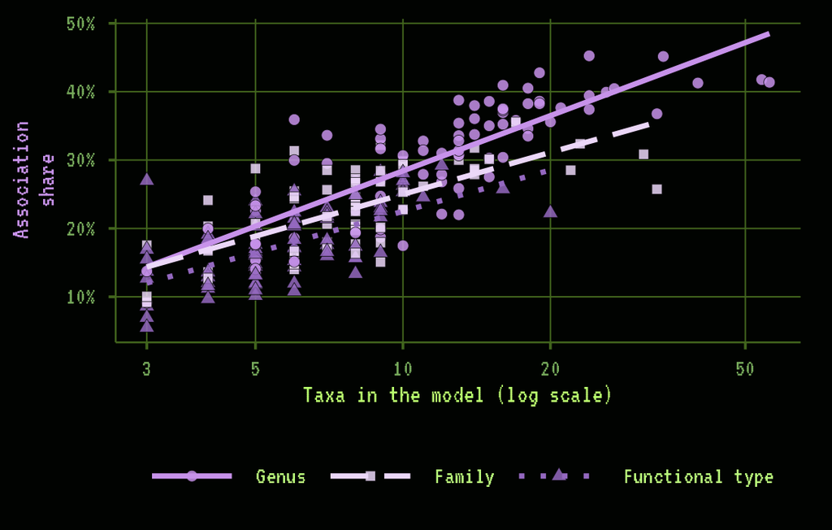

## Paleo predictions

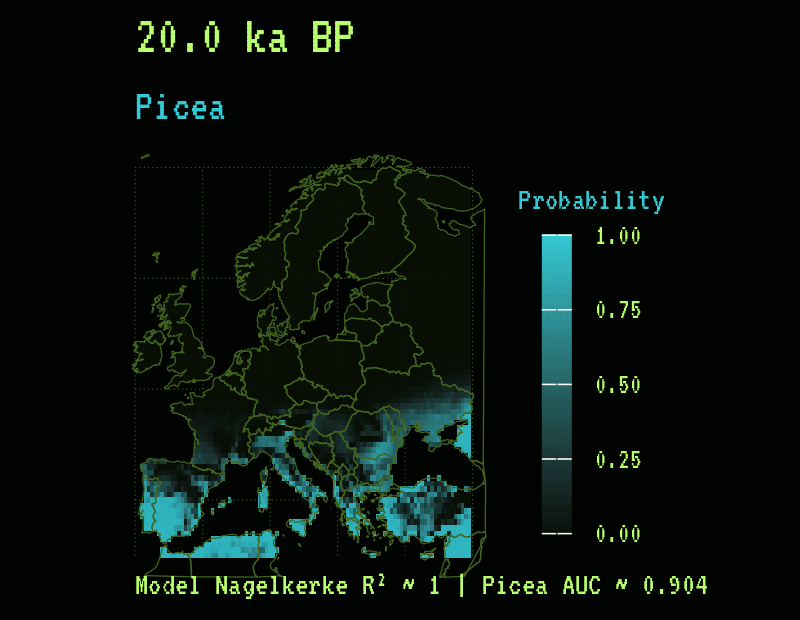

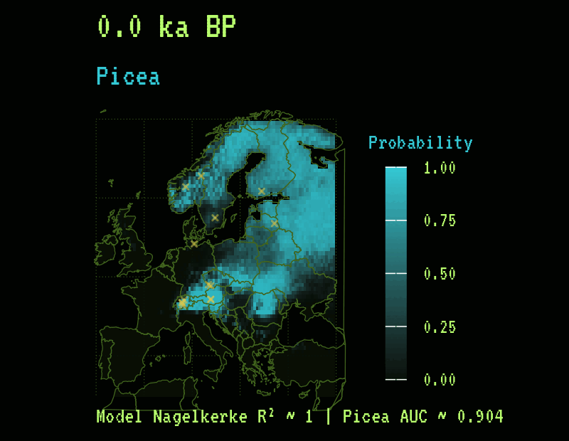

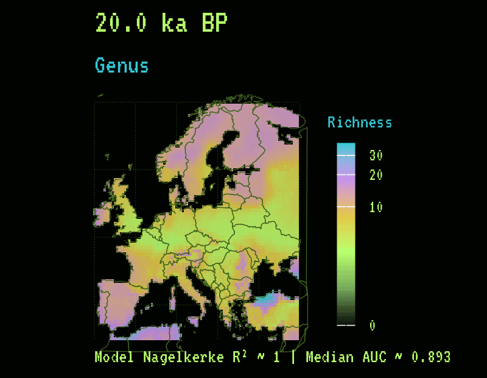

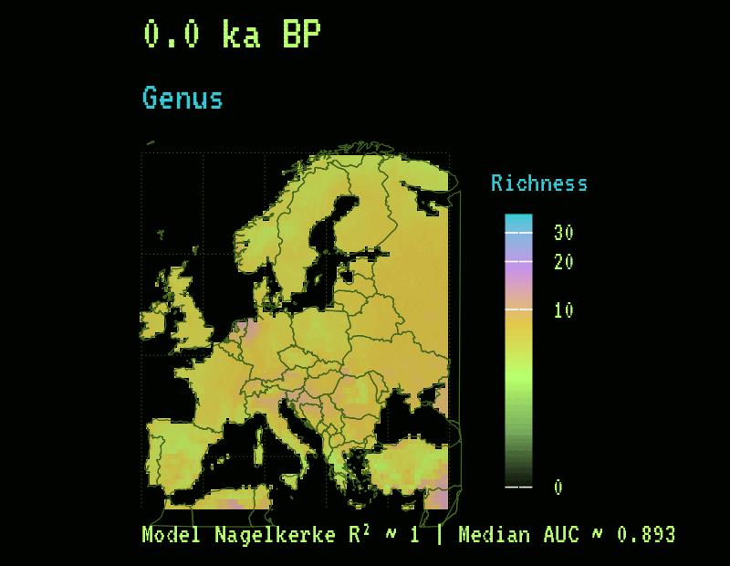

Current SDM models can reconstruct past-to-present biodiversity patterns and prepare the same machinery for future projection experiments

## Take-home messages

Summarising RESULTS together: spatial patterns, taxonomic resolution, temporal dynamics

Results are preliminary

Palaeoecological data CAN be used to reconstruct past biodiversity patterns and provide insights into ecological processes.

TAXONOMY: Increasing taxonomic resolution DOES have an impact on the spatial pattern of the association signal, but NOT in the expected direction

TIME: Co-occurrence structure IS responding to major environmental changes, but the association signal IS surprisingly stable through time.

MATRIX SIZE: The association signal DOES grow with the number of taxa; compare at equal size

In addition to contemporary single-species diversity models, palaeoecological data can be used to predict future biodiversity patterns and support conservation efforts.

## … termination

Execution complete.

Turning off non-essential systems

Thank you for your attention

…

## Presenter

[figure not shown]

Hi! I am Ondřej Mottl

- 🌐 [ondrejmottl.github.io](https://ondrejmottl.github.io/)
- 📧 ondrej.mottl(at)natur.cuni.cz
- 🦋 ondrejmottl.bsky.social

Assistant Professor at 🏛️[Charles University](https://cuni.cz/UK-1.html), Prague, 🇨🇿

Head of the 🧑‍💻[Laboratory of Quantitative Ecology](https://ondrejmottl.github.io/lab/about_the_lab.html)

Interested in macroecology, palaeoecology, biodiversity, and data science

[figure not shown]

[figure not shown]

## Presentation availability

This presentation is publicly available on the BIODYNAMICS project website

[figure not shown]

[figure not shown]

bit.ly/BIODYNAMICS_project

PDF backup contains static figures only; use the HTML deck for animations

MIT LICENSE | Supported by [Czech Science Foundation](https://gacr.cz/en/) grant GN23-06386I

## BIODYNAMICS PROJECT

talking to <ORACLE>:

Exploring biotic signals in vegetation assembly from the LGM to the Anthropocene

Ondrej Mottl

BES Annual Meeting 2026 || 14–17 December 2026 || Online

NARRATIVE INTERFACE: **ORACLE**

…/…/…

ANALYTICAL OUTPUTS: **REAL**

```
██████ ▄▄ ▄▄ ▄▄▄▄▄▄ ▄▄▄▄   ▄▄▄
██▄▄   ▀█▄█▀   ██   ██▄█▄ ██▀██
██▄▄▄▄ ██ ██   ██   ██ ██ ██▀██

 ▄▄▄▄ ▄▄    ▄▄ ▄▄▄▄  ▄▄▄▄▄  ▄▄▄▄
███▄▄ ██    ██ ██▀██ ██▄▄  ███▄▄
▄▄██▀ ██▄▄▄ ██ ████▀ ██▄▄▄ ▄▄██▀
```

## Climate versus space: no size effect

Control query: climate / (climate + space)

Result: flat

The size effect is specific to association

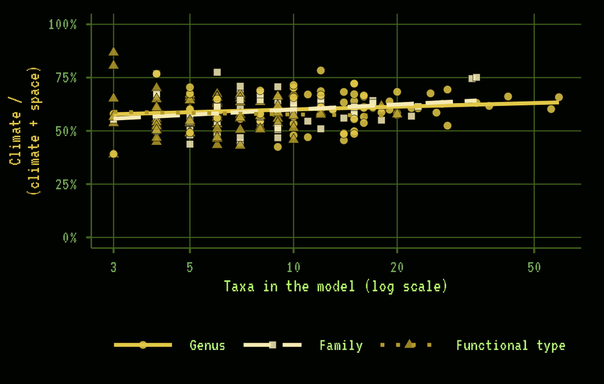

## At equal matrix size, the gradient reverses

Continental models hold about four times more genera than local ones

Adjusting every extent to the same number of taxa

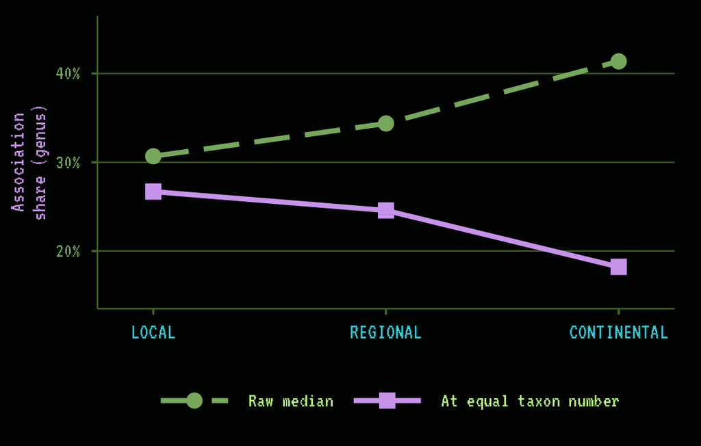

## Same genera across nested extents: first look

Following the same genera from a unit to the unit that contains it

Open symbols: difference at equal model size

Exploratory: not for quoting yet

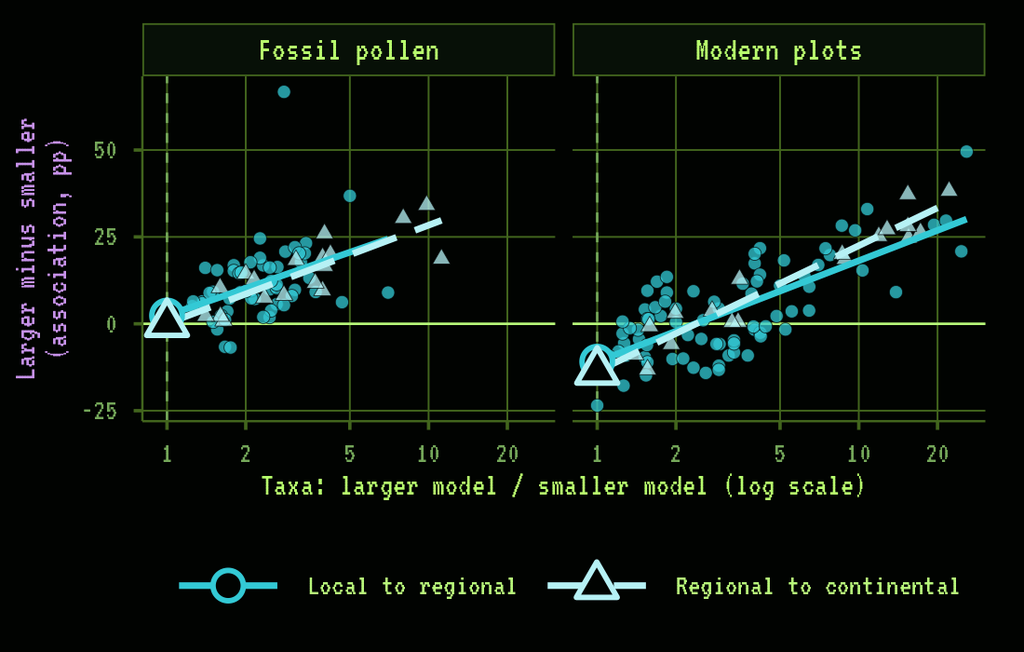

## And through time?

Taxa per slice rise toward the present

Fewest taxa, lowest association shares

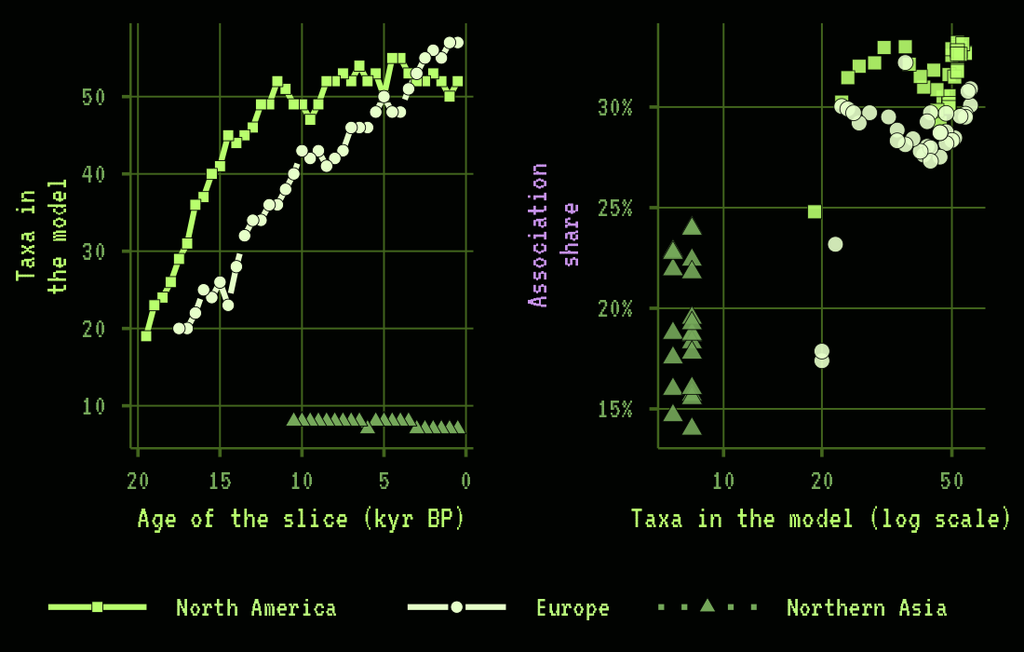

## Results of contemporary data

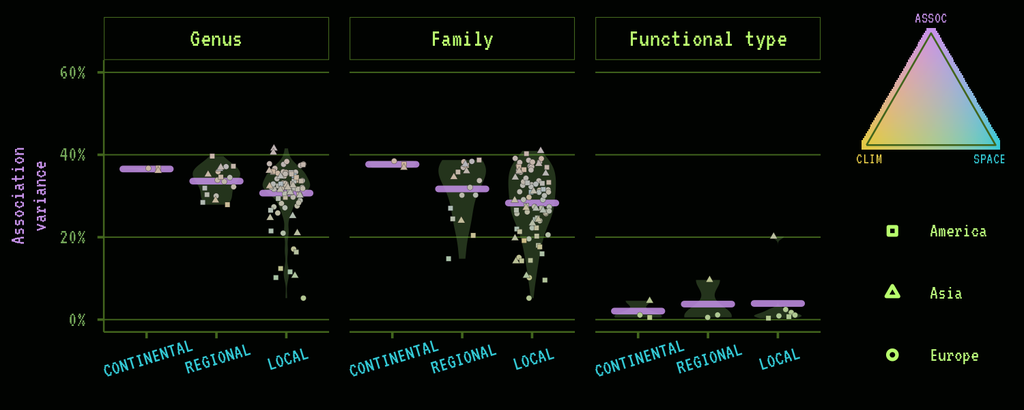

## Is it a issue of model quality?

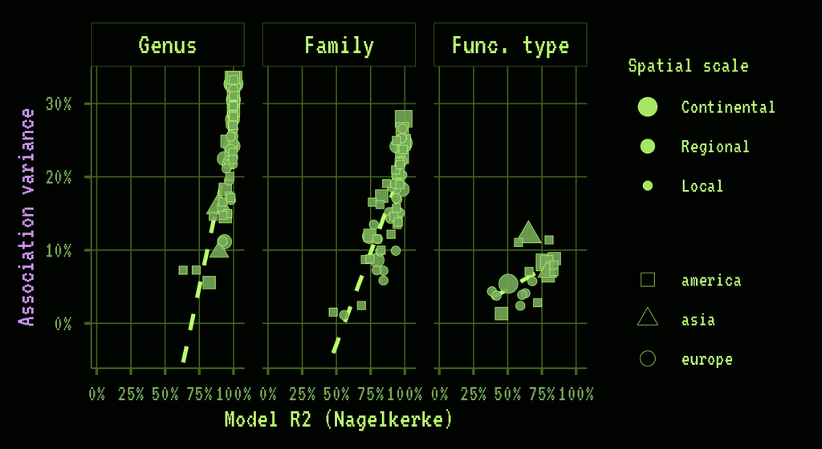

## Is there relationship between species-species association and network modularity?

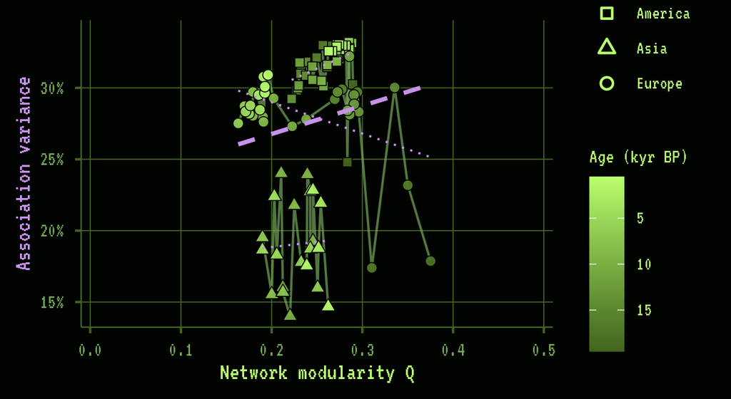

## Is there relationship between network modularity and network size?

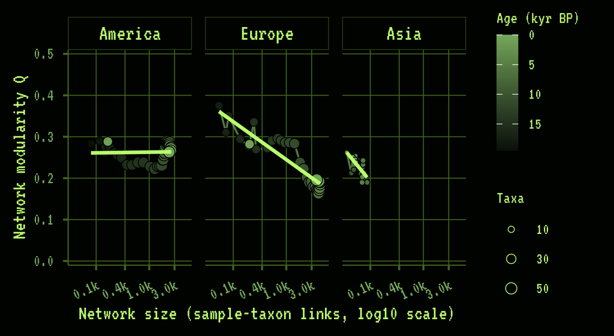

## How good predictor is the climate?

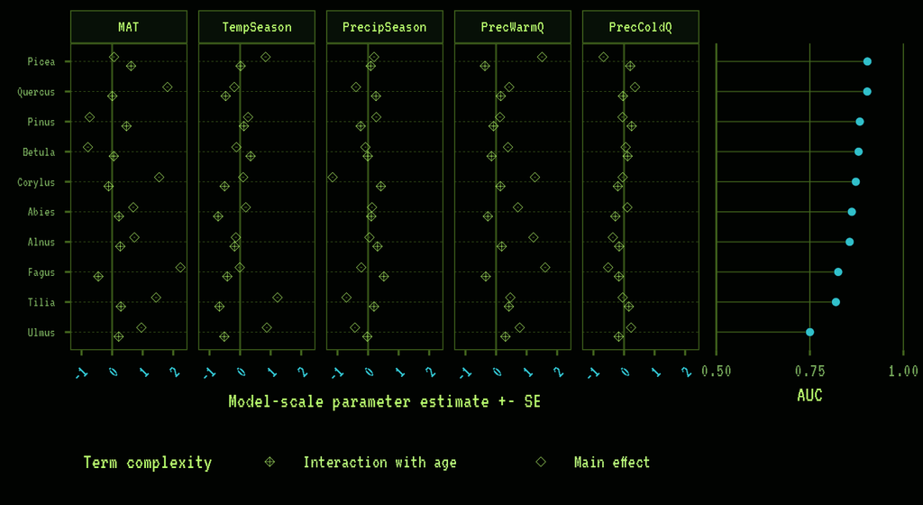

## How are the Functional Types generated ?

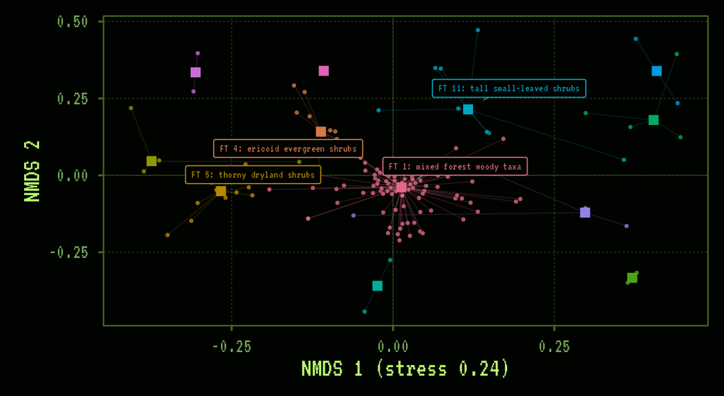